# Plotting a Catalog over a Kepler Full Frame Image File

This tutorial demonstrates how to access the WCS (World Coordinate System) from a full frame image file and use this data to plot a catalog of objects over the FFI.

[figure not shown]

[Introduction](#intro_ID)  
[Imports](#imports_ID)  
[Getting the Data](#data_ID)  
[File Information](#fileinfo_ID)  
[Displaying Image Data](#image_ID)  
[Overplotting Objects](#overplot_ID)  
[Additional Resources](#resources_ID)  
[About this Notebook](#about_ID)

## Introduction

**Full Frame Image file background:** A Full Frame Image (FFI) contains values for every pixel in each of the 84 channels. Standard calibrations, such as flat fields, blacks, and smears have been applied to the calibrated FFIs. These files also contain a World Coordinate System (WCS) that attaches RA and Dec coordinates to pixel x and y values.

**Some notes about the file:** kplr2009170043915_ffi-cal.fits  
The filename contains phrases for identification, where

- kplr = Kepler
- 2009170043915 = year 2009, day 170, time 04:39:15
- ffi-cal = calibrated FFI image

**Defining some terms:**

- **HDU:** Header Data Unit; a FITS file is made up of Header or Data units that contain information, data, and metadata relating to the file. The first HDU is called the primary, and anything that follows is considered an extension.
- **TIC:** TESS Input Catalog; a catalog of luminous sources on the sky to be used by the TESS mission. We will use the TIC in this notebook to query a catalog of objects that we will then plot over an image from Kepler.
- **WCS:** World Coordinate System; coordinates attached to each pixel of an N-dimensional image of a FITS file. For example, a specified celestial RA and Dec associated with pixel location in the image.

For more information about the Kepler mission and collected data, visit the [Kepler archive page](https://archive.stsci.edu/kepler/). To read more details about light curves and important data terms, look in the [Kepler archive manual](https://archive.stsci.edu/kepler/manuals/archive_manual.pdf#page=25).

Top of Page

## Imports

Let's start by importing some libraries to the environment:

- *numpy* to handle array functions
- *astropy.io fits* for accessing fits files
- *astropy.wcs WCS* to project the World Coordinate System on the plot
- *astropy.table Table* for creating tidy tables of the data
- *matplotlib.pyplot* for plotting data

```python
%matplotlib inline
import numpy as np
from astropy.io import fits
from astropy.wcs import WCS
from astropy.table import Table
import matplotlib.pyplot as plt
```

Top of Page

## Getting the Data

Start by importing libraries from Astroquery. For a longer, more detailed description using of Astroquery, please visit this [tutorial](https://github.com/spacetelescope/MAST-API-Notebooks/blob/master/MUG2018_APITutorial_Astroquery.ipynb) or read the Astroquery [documentation](https://astroquery.readthedocs.io/en/latest/#).

```python
from astroquery.mast import Mast
from astroquery.mast import Observations
```

Next, we need to find the data file. This is similar to searching for the data using the [MAST Portal](https://mast.stsci.edu/portal/Mashup/Clients/Mast/Portal.html) in that we will be using certain keywords to find the file. The object we are looking for is kplr2009170043915, collected by the Kepler spacecraft. We are searching for an FFI file of this object:

```python
kplrObs = Observations.query_criteria(obs_id="kplr2009170043915_84", obs_collection="KeplerFFI")
kplrProds = Observations.get_product_list(kplrObs[0])
yourProd = Observations.filter_products(kplrProds, extension='kplr2009170043915_ffi-cal.fits',
                                        mrp_only=False)
yourProd
```

| obsID str10 | obs_collection str9 | dataproduct_type str5 | obs_id str20 | description str22 | type str1 | dataURI str106 | productType str7 | productGroupDescription str28 | productSubGroupDescription str1 | productDocumentationURL str1 | project str6 | prvversion str1 | proposal_id str1 | productFilename str37 | size int64 | parent_obsid str10 |
| --- | --- | --- | --- | --- | --- | --- | --- | --- | --- | --- | --- | --- | --- | --- | --- | --- |
| 4000002693 | KeplerFFI | image | kplr2009170043915_84 | Full Frame Image (FFI) | C | mast:KeplerFFI/url/missions/kepler/ffi/kplr2009170043915_ffi-cal.fits | SCIENCE | Minimum Recommended Products | -- | -- | Kepler | -- | -- | kplr2009170043915_ffi-cal.fits | 407882880 | 4000002693 |

Now that we've found the data file, we can download it using the reults shown in the table above:

```
Observations.download_products(yourProd, mrp_only=False, cache=False)
```

```
Downloading URL https://mast.stsci.edu/api/v0.1/Download/file?uri=mast:KeplerFFI/url/missions/kepler/ffi/kplr2009170043915_ffi-cal.fits to ./mastDownload/KeplerFFI/kplr2009170043915_84/kplr2009170043915_ffi-cal.fits ... [Done]
```

| Local Path str76 | Status str8 | Message object | URL object |
| --- | --- | --- | --- |
| ./mastDownload/KeplerFFI/kplr2009170043915_84/kplr2009170043915_ffi-cal.fits | COMPLETE | None | None |

Top of Page

Reading FITS Extensions

Now that we have the file, we can start working with the data. We will begin by assigning a shorter name to the file to make it easier to use. Then, using the info function from astropy.io.fits, we can see some information about the FITS Header Data Units:

```
filename = "./mastDownload/KeplerFFI/kplr2009170043915_84/kplr2009170043915_ffi-cal.fits"
fits.info(filename)
```

```
Filename: ./mastDownload/KeplerFFI/kplr2009170043915_84/kplr2009170043915_ffi-cal.fits
No.    Name      Ver    Type      Cards   Dimensions   Format
  0  PRIMARY       1 PrimaryHDU      57   ()
  1  MOD.OUT 2.1    1 ImageHDU       100   (1132, 1070)   float32
  2  MOD.OUT 2.2    1 ImageHDU       100   (1132, 1070)   float32
  3  MOD.OUT 2.3    1 ImageHDU       100   (1132, 1070)   float32
  4  MOD.OUT 2.4    1 ImageHDU       100   (1132, 1070)   float32
  5  MOD.OUT 3.1    1 ImageHDU       100   (1132, 1070)   float32
  6  MOD.OUT 3.2    1 ImageHDU       100   (1132, 1070)   float32
  7  MOD.OUT 3.3    1 ImageHDU       100   (1132, 1070)   float32
  8  MOD.OUT 3.4    1 ImageHDU       100   (1132, 1070)   float32
  9  MOD.OUT 4.1    1 ImageHDU       100   (1132, 1070)   float32
 10  MOD.OUT 4.2    1 ImageHDU       100   (1132, 1070)   float32
 11  MOD.OUT 4.3    1 ImageHDU       100   (1132, 1070)   float32
 12  MOD.OUT 4.4    1 ImageHDU       100   (1132, 1070)   float32
```

[output cut: 72 more lines]

- **No. 0 (Primary):**  
  This HDU contains meta-data related to the entire file.

- **No. 1-84 (Image):**  
  Each of the 84 image extensions contains an array that can be plotted as an image. We will plot one in this tutorial along with catalog data.

Let's say we wanted to see more information about the header and extensions than what the fits.info command gave us. For example, we can access information stored in the header of any of the Image extensions (No.1 - 84, MOD.OUT). The following line opens the FITS file, writes the first HDU extension into header1, and then closes the file. Only 24 rows of data are displayed here but you can view them all by adjusting the range:

```
with fits.open(filename) as hdulist:
    header1 = hdulist[1].header

print(repr(header1[1:25]))
```

```
BITPIX  =                  -32 / array data type
NAXIS   =                    2 / NAXIS
NAXIS1  =                 1132 / length of first array dimension
NAXIS2  =                 1070 / length of second array dimension
PCOUNT  =                    0 / group parameter count (not used)
GCOUNT  =                    1 / group count (not used)
INHERIT =                    T / inherit the primary header
EXTNAME = 'MOD.OUT 2.1'        / name of extension
EXTVER  =                    1 / extension version number (not format version)
TELESCOP= 'Kepler  '           / telescope
INSTRUME= 'Kepler Photometer'  / detector type
CHANNEL =                    1 / CCD channel
SKYGROUP=                   81 / roll-independent location of channel
MODULE  =                    2 / CCD module
OUTPUT  =                    1 / CCD output
TIMEREF = 'SOLARSYSTEM'        / barycentric correction applied to times
TASSIGN = 'SPACECRAFT'         / where time is assigned
TIMESYS = 'TDB     '           / time system is barycentric JD
MJDSTART=       55001.17349214 / [d] start of observation in spacecraft MJD
MJDEND  =        55001.1939257 / [d] end of observation in spacecraft MJD
BJDREFI =              2454833 / integer part of BJD reference date
BJDREFF =           0.00000000 / fraction of the day in BJD reference date
TIMEUNIT= 'd       '           / time unit for TIME, TSTART and TSTOP
TSTART  =         168.67667104 / observation start time in BJD-BJDREF
```

Top of Page

Displaying Image Data

```
with fits.open(filename) as hdulist:
    header1 = hdulist[1].header

print(repr(header1[54:61]))
```

```
WCSAXES =                    2 / number of WCS axes
CTYPE1  = 'RA---TAN-SIP'       / Gnomonic projection + SIP distortions
CTYPE2  = 'DEC--TAN-SIP'       / Gnomonic projection + SIP distortions
CRVAL1  =    290.4620065226813 / RA at CRPIX1, CRPIX2
CRVAL2  =    38.32946356799192 / DEC at CRPIX1, CRPIX2
CRPIX1  =                533.0 / X reference pixel
CRPIX2  =                521.0 / Y reference pixel
```

Let's pick an image HDU and display its array. We can also choose to print the length of the array to get an idea of the dimensions of the image:

```
with fits.open(filename) as hdulist:
    imgdata = hdulist[1].data

print(len(imgdata))
print(imgdata)
```

```
1070
[[ 2.8926212e+01  5.7084761e+00  2.8518679e+00 ...  2.3335369e-02
   3.8872162e-01  2.4866710e+00]
 [ 2.5392172e+01  4.9826989e+00  2.3192320e+00 ... -3.5835370e-01
   9.4126135e-01  1.4343496e-01]
 [ 2.7359493e+01  5.5186005e+00  1.1480473e+00 ...  5.8914202e-01
  -2.0753877e+00  2.3046710e-01]
 ...
 [-3.8266034e+02 -9.6860485e+00  1.7396482e+01 ...  1.3947951e+00
  -8.3887035e-01  9.5944041e-01]
 [-3.8286859e+02 -5.6933088e+00  2.0129442e+01 ... -7.7534288e-01
   1.5140564e+00  1.3752979e+00]
 [-3.8489960e+02 -3.4747849e+00  1.5189555e+00 ...  1.0207459e+00
   6.7454106e-01 -2.0665376e-02]]
```

We can now plot this array as an image:

```
fig = plt.figure(figsize=(16,8))
plt.imshow(imgdata, cmap=plt.cm.gray)
plt.colorbar()
plt.clim(0,20000)
```

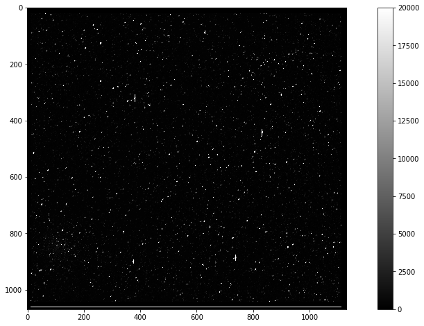

Now that we've seen the image and the WCS information, we can plot FFI with a WCS projection. To do this, first we will access the file header and assign a WCS object. Then we will plot the image with the projection, and add labels and a grid for usability:

```
hdu = fits.open(filename)[1]
wcs = WCS(hdu.header)

fig = plt.figure(figsize=(16,8))
ax = plt.subplot(projection=wcs)
im = ax.imshow(hdu.data, cmap=plt.cm.gray, origin='lower', clim=(0,20000))
fig.colorbar(im)

plt.title('FFI with WCS Projection')
ax.set_xlabel('RA [deg]')
ax.set_ylabel('Dec [deg]')
ax.grid(color='white', ls='solid')
```

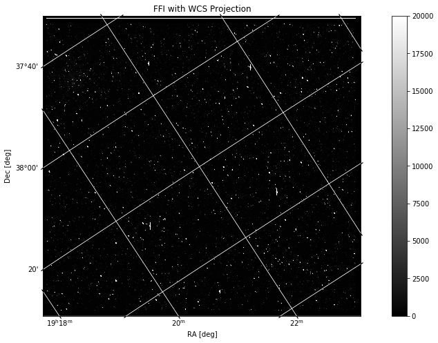

Top of Page

Getting the Catalog Data

Now that we have an image, we can use astroquery to retrieve a catalog of objects and overlay it onto the image. First, we will start with importing catalog data from astroquery:

```
from astroquery.mast import Catalogs
```

```
catalogData = Catalogs.query_region("290.4620065226813  38.32946356799192", radius="0.7 deg", catalog="TIC")
dattab = Table(catalogData)
dattab
```

| 122451116 | 290.458572 | 38.330704 | 8.65012 | -24.0384 | 17.834 | STAR | 2mass | 20180610 | -- | -- | -- | 19215005+3819505 | 1237668681001865024 | J192150.05+381950.1 | 2052812123437282560 | -- | 3231494 | tmgaia | 3.03321 | 3.033 | hsoy | -- | -- | -- | 70.553838 | 10.980659 | 302.66791 | 59.47125 | -- | … |
| --- | --- | --- | --- | --- | --- | --- | --- | --- | --- | --- | --- | --- | --- | --- | --- | --- | --- | --- | --- | --- | --- | --- | --- | --- | --- | --- | --- | --- | --- | --- |
| 122451103 | 290.460189 | 38.335473 | -6.45462 | -16.629 | 17.693 | STAR | 2mass | 20180610 | -- | -- | -- | 19215044+3820077 | 1237668681001862726 | -- | 2052812123437286656 | -- | 3231500 | tmgaia | 3.0447 | 3.04422 | hsoy | -- | -- | -- | 70.55877 | 10.981611 | 302.672881 | 59.475489 | -- | … |
| 122451132 | 290.454391 | 38.323635 | -5.55404 | -0.934956 | 16.828 | STAR | 2mass | 20180610 | -- | -- | -- | 19214905+3819250 | 1237668681001862417 | -- | 2052811745480155520 | -- | 3231481 | tmgaia | 2.35572 | 2.35563 | hsoy | -- | -- | -- | 70.545901 | 10.980504 | 302.657892 | 59.465347 | 18.719 | … |
| 122451135 | 290.455889 | 38.322012 | -1.6626 | -13.8329 | 15.781 | STAR | 2mass | 20180610 | -- | -- | 642-067566 | 19214941+3819192 | 1237668681001862412 | -- | 2052811539321725184 | -- | 3231488 | tmgaia | 2.2322 | 2.2322 | hsoy | -- | -- | -- | 70.544941 | 10.978736 | 302.659243 | 59.463465 | 17.31 | … |
| 122451138 | 290.459003 | 38.320724 | -- | -- | 14.832 | STAR | 2mass | 20180610 | -- | -- | 642-067569 | 19215016+3819146 | 1237668681001862408 | -- | 2052811539321722752 | -- | 3231495 | tmgaia | -- | -- | -- | -- | -- | -- | 70.544853 | 10.975976 | 302.663174 | 59.461558 | 14.795 | … |
| 122451143 | 290.460553 | 38.319639 | 2.57982 | -4.77194 | 13.371 | STAR | 2mass | 20180610 | -- | -- | 642-067570 | 19215053+3819107 | 1237668681001862406 | J192150.50+381911.1 | 2052811539321899776 | -- | 3231502 | tmgaia | 1.72102 | 1.74743 | hsoy | -- | -- | -- | 70.544404 | 10.974407 | 302.664892 | 59.460181 | 15.112 | … |
| 122451145 | 290.46656 | 38.319223 | 0.381496 | -4.49348 | 17.112 | STAR | 2mass | 20180610 | -- | -- | -- | 19215197+3819092 | 1237668681001862421 | J192151.97+381909.2 | 2052811917278842752 | -- | 3231515 | tmgaia | 2.7951 | 2.79486 | hsoy | -- | -- | -- | 70.54613 | 10.96999 | 302.673588 | 59.458492 | -- | … |
| 122451112 | 290.448791 | 38.333086 | -2.41812 | -3.72197 | 15.458 | STAR | 2mass | 20180610 | -- | -- | 642-067561 | 19214771+3819591 | 1237668681001862720 | J192147.70+381959.1 | 2052812123437284608 | -- | 3231468 | tmgaia | 2.18082 | 2.18065 | hsoy | -- | -- | -- | 70.55259 | 10.988599 | 302.654665 | 59.475641 | 17.815 | … |
| 122451083 | 290.460477 | 38.341217 | -- | -- | 14.764 | STAR | 2mass | 20180610 | -- | -- | -- | 19215051+3820283 | -- | -- | -- | -- | 3231501 | 2mass | -- | -- | -- | -- | -- | -- | 70.564129 | 10.983928 | 302.676406 | 59.480952 | 12.29 | … |
| 122451146 | 290.454169 | 38.319199 | -- | -- | 15.387 | STAR | 2mass | 20180610 | -- | -- | 642-067565 | 19214900+3819091 | 1237668681001862411 | J192149.03+381908.0 | 2052811539321721600 | -- | 3231479 | tmmgaia | -- | -- | -- | -- | -- | -- | 70.541763 | 10.978715 | 302.655174 | 59.461129 | 16.604 | … |
| ... | ... | ... | ... | ... | ... | ... | ... | ... | ... | ... | ... | ... | ... | ... | ... | ... | ... | ... | ... | ... | ... | ... | ... | ... | ... | ... | ... | ... | ... | … |
| 122377612 | 290.407466 | 39.028113 | -12.7285 | -19.1484 | 17.8 | STAR | 2mass | 20180610 | -- | -- | -- | 19213779+3901412 | 1237672005833656901 | -- | 2052911045123553920 | -- | 3950604 | tmgaia | 2.42235 | 2.42238 | hsoy | -- | -- | -- | 71.175228 | 11.321672 | 302.974725 | 60.152551 | 19.276 | … |
| 122682152 | 290.929023 | 37.733971 | -9.55346 | 0.352084 | 16.498 | STAR | 2mass | 20180610 | -- | -- | 639-066711 | 19234296+3744022 | 1237668680465253984 | -- | 2052547759609785344 | -- | 2441118 | tmgaia | 2.30428 | 2.30428 | hsoy | -- | -- | -- | 70.175488 | 10.384697 | 303.043874 | 58.795825 | 18.025 | … |
| 122716866 | 291.06185 | 38.84918 | -2.05088 | -4.17517 | 15.995 | STAR | 2mass | 20180610 | -- | -- | -- | 19241484+3850570 | 1237672005833916826 | J192414.83+385057.0 | 2052942724805797248 | -- | 3745556 | tmgaia | 2.25013 | 2.25014 | hsoy | -- | -- | -- | 71.239373 | 10.785831 | 303.850613 | 59.837521 | 17.164 | … |
| 394247097 | 289.71909 | 37.944096 | -3.63553 | 3.17979 | 16.657 | STAR | 2mass | 20180610 | -- | -- | -- | 19185258+3756387 | 1237672004223044450 | J191852.56+375638.3 | 2051307647935387648 | -- | 2705818 | tmgaia | 2.28735 | 2.28736 | hsoy | -- | -- | -- | 69.940713 | 11.335491 | 301.364926 | 59.254739 | 19.635 | … |
| 122781692 | 291.162506 | 37.897939 | -0.93578 | -22.4732 | 17.643 | STAR | 2mass | 20180610 | -- | -- | -- | 19243900+3753526 | 1237672004760375294 | J192439.00+375352.3 | 2052573185820335104 | -- | 2574438 | tmgaia | 2.26839 | 2.26841 | hsoy | -- | -- | -- | 70.408199 | 10.292522 | 303.474104 | 58.902483 | 20.3 | … |
| 122365366 | 290.186408 | 37.664025 | 17.2627 | -33.4491 | 17.602 | STAR | 2mass | 20180610 | -- | -- | -- | 19204473+3739505 | -- | -- | 2051098706366028160 | -- | 2297365 | tmgaia | 2.23893 | 2.23894 | hsoy | -- | -- | -- | 69.847811 | 10.881111 | 301.913905 | 58.887099 | 18.462 | … |
| 122377588 | 290.294512 | 39.017124 | -6.151 | -18.1038 | 12.344 | STAR | 2mass | 20180610 | -- | -- | 646-068620 | 19211068+3901016 | 1237672005833654535 | J192110.67+390101.3 | 2052922658714222080 | 50456098 | 3950220 | tmgaia | 1.04763 | 1.08676 | hsoy | -- | -- | -- | 71.126128 | 11.395862 | 302.79918 | 60.166392 | 13.295 | … |
| 122507569 | 290.442823 | 37.62964 | -15.5508 | -3.92094 | 16.783 | STAR | 2mass | 20180610 | -- | -- | -- | 19214627+3737467 | 1237672004223307562 | -- | 2051100012035349888 | -- | 2298622 | tmgaia | 2.79882 | 2.37459 | hsoy | -- | -- | -- | 69.907166 | 10.683621 | 302.274344 | 58.79977 | 17.874 | … |
| 122225751 | 290.037636 | 38.946001 | -0.152006 | -13.1305 | 14.124 | STAR | 2mass | 20180610 | -- | -- | 645-068673 | 19200903+3856456 | 1237668681538473186 | J192009.03+385645.5 | 2052900840284543744 | -- | 3845501 | tmgaia | 2.19761 | 2.19762 | hsoy | -- | -- | -- | 70.972262 | 11.544834 | 302.374024 | 60.153054 | 17.263 | … |
| 122449579 | 290.470147 | 39.029433 | 0.922644 | -3.06345 | 14.91 | STAR | 2mass | 20180610 | -- | -- | 646-068770 | 19215283+3901459 | 1237672005833655447 | J192152.82+390145.8 | 2052916164724570112 | -- | 3950819 | tmgaia | 2.1743 | 2.1743 | hsoy | -- | -- | -- | 71.198118 | 11.278441 | 303.069398 | 60.14023 | 16.656 | … |